[Edit on GitHub](https://github.com/AlgebraicJulia/Decapodes.jl/blob/main/docs/src/bc_debug.md)

# Simulation Setup

This tutorial showcases some of the other features included in the Decapodes.jl package. Currently, these features are the treatment of boundary conditions and the simulation debugger interface. To begin, we set up the same advection-diffusion problem presented in the Overview section. As before, we define the Diffusion, Advection, and Superposition components, and now include a BC (Bounday Condition) component. Decapodes.jl interprets any `Hom` which begins with a `∂` as a boundary condition. These boundary conditions recieve special treatment at the scheduling step. Below we show the graphical rendering of this boundary condition diagram, which we will use to impose a Dirichlet condition on the time derivative of concentration at the mesh boundary.

```julia
using Decapodes, Decapodes.Diagrams, Decapodes.OpenDiagrams
using Catlab.Present, Catlab.Graphics, Catlab.Programs

@present DiffusionQuantities <: Decapodes2D begin
  k::Hom(Form1(X), Form1(X))    # diffusivity (usually scalar multiplication)
  ∂C::Hom(Form0(X), Form0(X))   # concentration boundary condition
end;

Diffusion = @decapode DiffusionQuantities begin
  C::Form0{X}
  ϕ::Form1{X}

  # Fick's first law
  ϕ ==  k(d₀{X}(C))
end

Advection = @decapode DiffusionQuantities begin
  C::Form0{X}
  (V, ϕ)::Form1{X}
  ϕ == ∧₀₁{X}(C,V)
end

Superposition = @decapode DiffusionQuantities begin
  (C, Ċ)::Form0{X}
  (ϕ, ϕ₁, ϕ₂)::Form1{X}

  ϕ == ϕ₁ + ϕ₂
  Ċ == ⋆₀⁻¹{X}(dual_d₁{X}(⋆₁{X}(ϕ)))
  ∂ₜ{Form0{X}}(C) == Ċ
end

BoundaryConditions = @decapode DiffusionQuantities begin
  (Ċ, Ċ_bound)::Form0{X}
  ∂C(Ċ) == Ċ_bound
end

draw_diagram(BoundaryConditions)
```

[figure not shown]

As before, we compose these physics components over our wiring diagram.

```julia
compose_diff_adv = @relation (C, V) begin
  diffusion(C, ϕ₁)
  advection(C, ϕ₂, V)
  bc(Ċ)
  superposition(ϕ₁, ϕ₂, ϕ, Ċ, C)
end

to_graphviz(compose_diff_adv, box_labels=:name, junction_labels=:variable,
            graph_attrs=Dict(:start => "2"))
```

[figure not shown]

```julia
DiffusionAdvection = oapply(compose_diff_adv,
                  [OpenDiagram(Diffusion, [:C, :ϕ]),
                   OpenDiagram(Advection, [:C, :ϕ, :V]),
                   OpenDiagram(BoundaryConditions, [:Ċ]),
                   OpenDiagram(Superposition, [:ϕ₁, :ϕ₂, :ϕ, :Ċ, :C])])

draw_diagram(DiffusionAdvection.functor)
```

[figure not shown]

When this is scheduled, Decapodes will apply any boundary conditions immediately after the impacted value is computed. This implementation choice ensures that this boundary condition holds true for any variables dependent on this variable, though also means that the boundary conditions on a variable have no immediate impact on the variables this variable is dependent on.

Below, we see the generated schedule, which shows that the final operation executed on the data is the boundary condition we are enforcing on the change in concentration.

```julia
using Decapodes.Schedules

explicit_ts = diag2dwd(DiffusionAdvection.functor)
to_graphviz(explicit_ts, orientation=LeftToRight)
```

[figure not shown]

Next we import the mesh we will use. In this case, we are wanting to impose boundary conditions and so we will use the `plot_mesh` from the previous example instead of the mesh with periodic boundary conditions. Because the mesh is only a primal mesh, we also generate and subdivide the dual mesh.

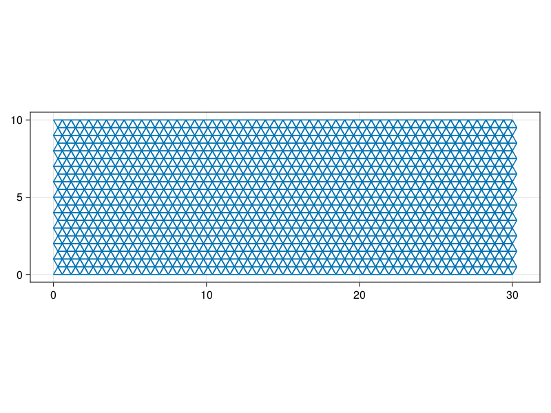

```julia
using Catlab.CategoricalAlgebra
using CombinatorialSpaces, CombinatorialSpaces.DiscreteExteriorCalculus
using CairoMakie
using JSON
using HTTP: get

plot_mesh = parse_json_acset(EmbeddedDeltaSet2D{Bool, Point3{Float64}},
                                 String(get("https://raw.githubusercontent.com/AlgebraicJulia/Decapodes.jl/main/docs/assets/meshes/plot_mesh.json").body))

# Generate the dual mesh
plot_mesh_dual = EmbeddedDeltaDualComplex2D{Bool, Float64, Point3{Float64}}(plot_mesh)
# Calculate distances and subdivisions for the dual mesh
subdivide_duals!(plot_mesh_dual, Circumcenter())


fig, ax, ob = wireframe(plot_mesh)
ax.aspect = AxisAspect(3.0)
fig
```

Finally, we define our operators, generate the simulation function, and compute the simulation. Note that when we define the boudary condition operator, we hardcode the boundary indices and values into the operator itself. We also move the initial concentration to the left, so that we are able to see a constant concentration on the left boundary which will act as a source in the flow. The modified initial condition is shown below:

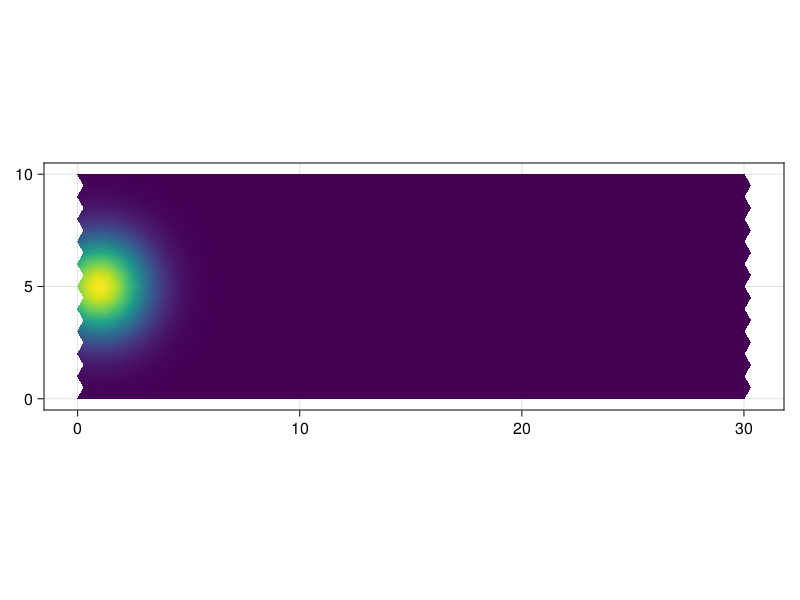

```julia
using LinearAlgebra
using Decapodes.Examples, Decapodes.Simulations
using CombinatorialSpaces.DiscreteExteriorCalculus: ∧

funcs = sym2func(plot_mesh_dual)

funcs[:k] = Dict(:operator => 0.05 * I(ne(plot_mesh_dual)), :type => MatrixFunc())
funcs[:⋆₁] = Dict(:operator => ⋆(Val{1}, plot_mesh_dual, hodge=DiagonalHodge()),
                  :type => MatrixFunc());
funcs[:∧₀₁] = Dict(:operator => (r, c,v)->r .= ∧(Tuple{0,1}, plot_mesh_dual, c, v), :type => InPlaceFunc())

boundary = Examples.boundary_inds(Val{0}, plot_mesh)
funcs[:∂C] = Dict(:operator => (∂ċ, ċ)->(∂ċ .= ċ; ∂ċ[boundary] .= 0), :type => InPlaceFunc())


using Distributions
c_dist = MvNormal([1, 5], [1.5, 1.5])
c = [pdf(c_dist, [p[1], p[2]]) for p in plot_mesh_dual[:point]]

fig, ax, ob = mesh(plot_mesh; color=c[1:nv(plot_mesh)])
ax.aspect = AxisAspect(3.0)
fig
```

And the simulation result is then computed and visualized below.

```julia
using OrdinaryDiffEq
func, code = gen_sim(explicit_ts, funcs, plot_mesh_dual; autodiff=false, params = [:V]);

velocity(p) = [-0.5, 0.0, 0.0]
v = ♭(plot_mesh_dual, DualVectorField(velocity.(plot_mesh_dual[triangle_center(plot_mesh_dual),:dual_point]))).data

prob = ODEProblem(func, c, (0.0, 100.0))
sol = solve(prob, Tsit5(), p=v);

# Plot the result
times = range(0.0, 100.0, length=150)
colors = [sol(t)[1:nv(plot_mesh)] for t in times]

# Initial frame
fig, ax, ob = mesh(plot_mesh, color=colors[1], colorrange = extrema(vcat(colors...)))
ax.aspect = AxisAspect(3.0)
Colorbar(fig[1,2], ob)
framerate = 30

# Animation
record(fig, "diff_adv_right.gif", range(0.0, 100.0; length=150); framerate = 30) do t
ob.color = sol(t)[1:nv(plot_mesh)]
end
```

```
"diff_adv_right.gif"
```

[figure not shown]

# Debug the Simulation

The benefit of having the computation graph which we generated above means that we have the opportunity to inspect the simulation at different stages of computation. Since each wire in the computation diagram has the data of a particular form on the mesh, this data can be visualized. The first step of getting at this data, though, is understanding the index associated with each wire. This key between indices and wires can be generated with the `sim_key` function.

```julia
using Decapodes.Debug

sim_key(explicit_ts)
```

[figure not shown]

Another key piece of data is what the initial state is at the time-step you are debugging. We choose the time step `t = 10` for this example, shown below.

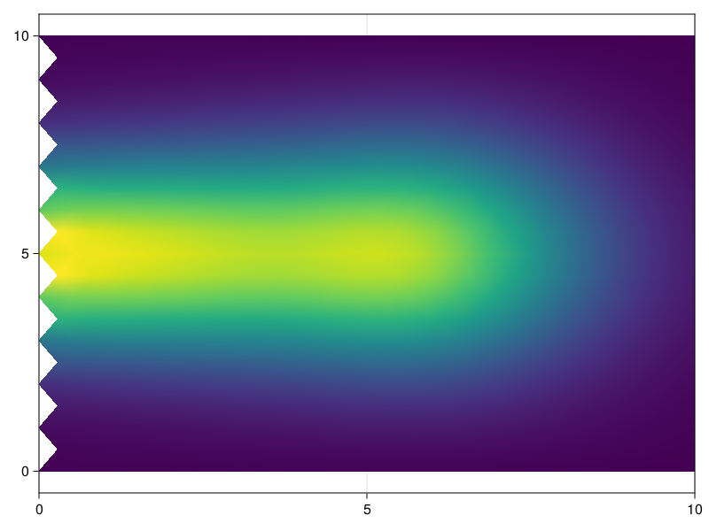

```julia
t = 10.0
fig, ax, ob = mesh(plot_mesh; color=sol(t)[1:nv(plot_mesh_dual)])
xlims!(ax, (0,10.0))
fig
```

Now we can see what the value is of the result of the product between velocity and the concentration.

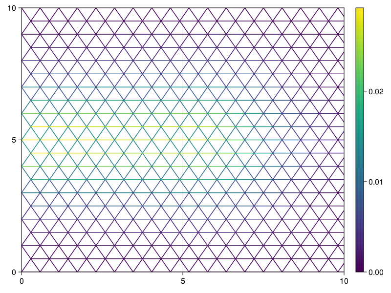

```julia
fig, ax, ob = draw_wire(plot_mesh, plot_mesh_dual, explicit_ts, func, sol(10.0), 2;p = v, xlim=(0, 10.0), ylim=(0.0,10.0))
fig
```

Now, this information doesn't seem all that useful at first glance. The result is basically a heatmap of the magnitude of the vector field across each edge of the mesh. Here, we see that this product has a greater magnitude on edges that are both aligned with the flow and have a high concentraiton at that point.

Something which is a little more useful is to includ arrows! By using the `use_arrows` keyword argument, we are able to get arrows, directed along the mesh edge elements, which show the direction of the vectorfield at that point. The color of these arrows shows the magnitude of the vectorfield in that direction. Note that this method of plotting arrows with CairoMakie is fairly computationally expensive, so as the `n_arrows` argument increases, so will the time it takes to render.

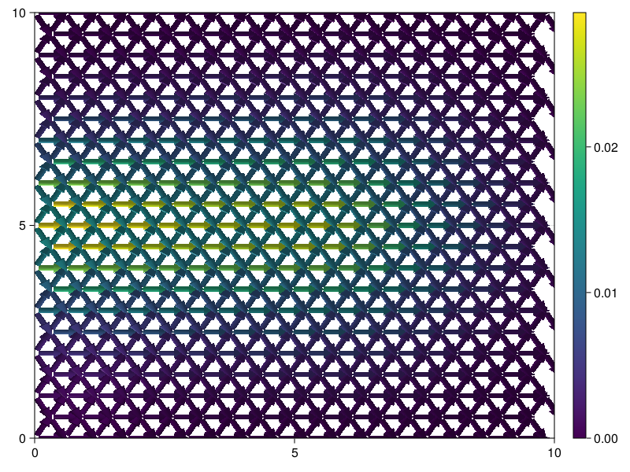

```julia
fig, ax, ob = draw_wire(plot_mesh, plot_mesh_dual, explicit_ts, func, sol(10.0), 2;p = v, xlim=(0, 10.0), ylim=(0.0,10.0), use_arrows=true, n_arrows=1200)
fig
```

Note that all of the arrows from the result of the product are pointing in the direction of flow. This intuitively makes sense for how the concentration flow vectorfield should look.

Below, we show the concentration flow resulting just from the gradient.

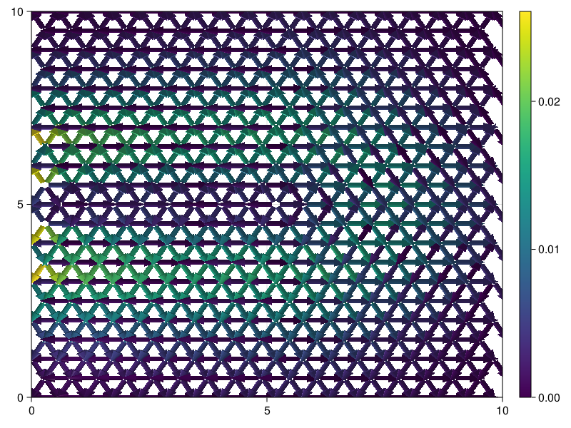

```julia
fig, ax, ob = draw_wire(plot_mesh, plot_mesh_dual, explicit_ts, func, sol(10.0), 7;p = v, xlim=(0, 10.0), ylim=(0.0,10.0), use_arrows=true, n_arrows=1200)
fig
```

Here, we see that the arrows are pointing away from areas of high concentration to areas of low concentration, and that the magnitude of the arrows grows greater as the slope of concentration is greater.

Next, we can show what happens after the effects of diffusion and advection are added together.

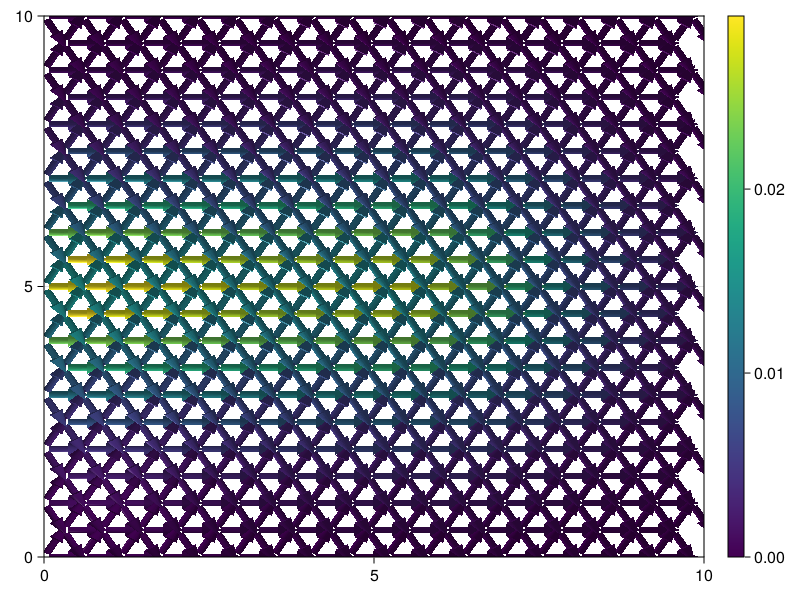

```julia
fig, ax, ob = draw_wire(plot_mesh, plot_mesh_dual, explicit_ts, func, sol(10.0), 4;p = v, xlim=(0, 10.0), ylim=(0.0,10.0), use_arrows=true, n_arrows=1200)
fig
```

Finally, in order to compute the change of concentration, we visualize what the resulting change in concentration is.

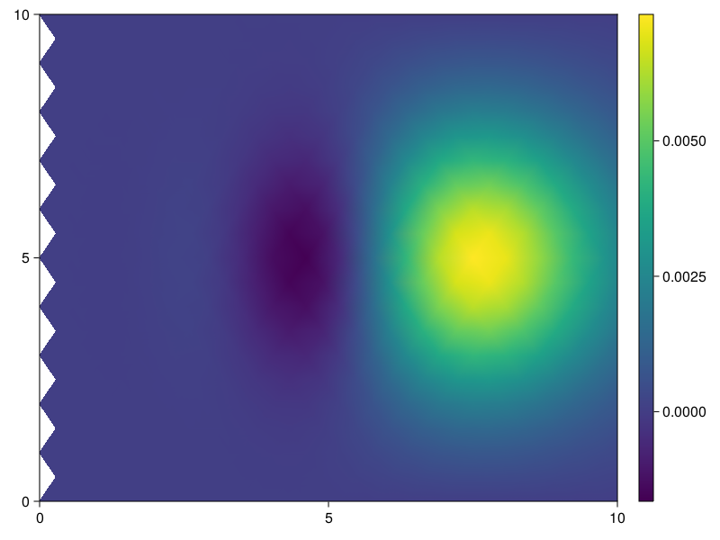

```julia
fig, ax, ob = draw_wire(plot_mesh, plot_mesh_dual, explicit_ts, func, sol(10.0), 3;p = v, xlim=(0, 10.0), ylim=(0.0,10.0), use_arrows=true, n_arrows=1200)
fig
```

Here, we can see the positive change which is weighted heavily to the right of the existing distribution, and the slight negative change which follows from where the distribution is flowing.